# Problem Set 1

Due April 11th at 5:30pm -- at the start of the class so we can discuss the solutions in class.

### Before You Start

Make sure to at least take a basic tutorial in the IPython notebook, otherwise you'll be totally lost. For this problem set, you should download flights.csv.bz2 and weather.csv.bz2 datasets from Canvas (files-data). Rename the notebook to LASTNAME_FIRSTNAME-PS1.ipynb.

When done, please submit

1. the notebook itself
2. the rendered html or pdf of it.

## About the Problem Set:

This problem set is rather similar to ones used for R, dplyr, and flights data. Just we use python and pandas.

In this problem set you will perform a basic exploratory analysis on an example dataset, bringing to bear all of your new skills in data manipulation and visualization. You will be required to submit well commented python code, documenting all code used in this problem set, along with a write up answering all questions below. Use figures as appropriate to support your answers, and when required by the problem.

## Preliminaries

You should also make sure the following libraries load correctly (click on the box below and hit Ctrl-Enter)

```python
#IPython is what you are using now to run the notebook
import IPython
print( "IPython version:      %6.6s (need at least 1.0)" % IPython.__version__)

# Numpy is a library for working with Arrays
import numpy as np
print( "Numpy version:        %6.6s (need at least 1.7.1)" % np.__version__)

# SciPy implements many different numerical algorithms
import scipy as sp
print( "SciPy version:        %6.6s (need at least 0.12.0)" % sp.__version__)

# Pandas makes working with data tables easier
import pandas as pd
print( "Pandas version:       %6.6s (need at least 0.11.0)" % pd.__version__)

# Module for plotting
import matplotlib.pyplot as plt
import matplotlib
print( "Matplotlib version:    %6.6s (need at least 1.2.1)" %
       matplotlib.__version__)
%matplotlib inline
# necessary for in-line graphics

# SciKit Learn implements several Machine Learning algorithms
import sklearn
print( "Scikit-Learn version: %6.6s (need at least 0.13.1)" % sklearn.__version__)
```

```
IPython version:       6.2.1 (need at least 1.0)
Numpy version:        1.14.2 (need at least 1.7.1)
SciPy version:         1.0.1 (need at least 0.12.0)
Pandas version:       0.22.0 (need at least 0.11.0)
Matplotlib version:     2.2.2 (need at least 1.2.1)
Scikit-Learn version: 0.19.1 (need at least 0.13.1)
```

```python
## Let's read the data and print some summary information
## adjust the path for your file system!
flights_df= pd.read_csv('data/flights.csv.bz2')
weather_df = pd.read_csv('data/weather.csv.bz2')
```

```python
print (flights_df.shape)
print (flights_df.columns)
print (flights_df.dtypes)
```

```
(336776, 17)
Index(['Unnamed: 0', 'year', 'month', 'day', 'dep_time', 'dep_delay',
       'arr_time', 'arr_delay', 'carrier', 'tailnum', 'flight', 'origin',
       'dest', 'air_time', 'distance', 'hour', 'minute'],
      dtype='object')
Unnamed: 0      int64
year            int64
month           int64
day             int64
dep_time      float64
dep_delay     float64
arr_time      float64
arr_delay     float64
carrier        object
tailnum        object
flight          int64
origin         object
dest           object
air_time      float64
distance        int64
hour          float64
minute        float64
dtype: object
```

```python
flights_df.dest.unique()
flights_df.head(10)
```

|  | Unnamed: 0 | year | month | day | dep_time | dep_delay | arr_time | arr_delay | carrier | tailnum | flight | origin | dest | air_time | distance | hour | minute |
| --- | --- | --- | --- | --- | --- | --- | --- | --- | --- | --- | --- | --- | --- | --- | --- | --- | --- |
| 0 | 1 | 2013 | 1 | 1 | 517.0 | 2.0 | 830.0 | 11.0 | UA | N14228 | 1545 | EWR | IAH | 227.0 | 1400 | 5.0 | 17.0 |
| 1 | 2 | 2013 | 1 | 1 | 533.0 | 4.0 | 850.0 | 20.0 | UA | N24211 | 1714 | LGA | IAH | 227.0 | 1416 | 5.0 | 33.0 |
| 2 | 3 | 2013 | 1 | 1 | 542.0 | 2.0 | 923.0 | 33.0 | AA | N619AA | 1141 | JFK | MIA | 160.0 | 1089 | 5.0 | 42.0 |
| 3 | 4 | 2013 | 1 | 1 | 544.0 | -1.0 | 1004.0 | -18.0 | B6 | N804JB | 725 | JFK | BQN | 183.0 | 1576 | 5.0 | 44.0 |
| 4 | 5 | 2013 | 1 | 1 | 554.0 | -6.0 | 812.0 | -25.0 | DL | N668DN | 461 | LGA | ATL | 116.0 | 762 | 5.0 | 54.0 |
| 5 | 6 | 2013 | 1 | 1 | 554.0 | -4.0 | 740.0 | 12.0 | UA | N39463 | 1696 | EWR | ORD | 150.0 | 719 | 5.0 | 54.0 |
| 6 | 7 | 2013 | 1 | 1 | 555.0 | -5.0 | 913.0 | 19.0 | B6 | N516JB | 507 | EWR | FLL | 158.0 | 1065 | 5.0 | 55.0 |
| 7 | 8 | 2013 | 1 | 1 | 557.0 | -3.0 | 709.0 | -14.0 | EV | N829AS | 5708 | LGA | IAD | 53.0 | 229 | 5.0 | 57.0 |
| 8 | 9 | 2013 | 1 | 1 | 557.0 | -3.0 | 838.0 | -8.0 | B6 | N593JB | 79 | JFK | MCO | 140.0 | 944 | 5.0 | 57.0 |
| 9 | 10 | 2013 | 1 | 1 | 558.0 | -2.0 | 753.0 | 8.0 | AA | N3ALAA | 301 | LGA | ORD | 138.0 | 733 | 5.0 | 58.0 |

## Some Tips

- This assignment involves extensive Data frame splitting and aggregation. You should look into the details of the methods groupby, transform, sum, count, mean etc
- Many of the tasks in the assignment can be done either through the Pandas Data Frame or by converting the data frames to Series. Many of the methods in the numpy are applicable to Series only. When stuck, try to explore the type of object (Pandas Data Frame or Numpy Series) you are dealing with.

## Question 1

Let’s explore flights from NYC to Seattle. Use the flights dataset to answer the following questions.

(a) How many flights were there from NYC airports to Seattle in 2013?

```python
#We only have data for the year 2013. As we can see below
flights_df.year.unique()
```

```
array([2013], dtype=int64)
```

```python
#Find number of flights from New York City to Seattle.
nyctosea = flights_df[flights_df.dest == 'SEA']
nyctosea['Unnamed: 0'].count()
```

```
3923
```

There have been 3923 flights from New York City to Seattle, we do not slice according to number since the dataset only contains flights from 2013

(b) How many airlines fly from NYC to Seattle?

```python
#Find unique carriers flying
print('Airlines from NYC to SEA')
print(nyctosea['carrier'].unique())
```

```
Airlines from NYC to SEA
['AS' 'DL' 'UA' 'B6' 'AA']
```

5 airlines fly from NYC to Seattle. They are Alaska Airlines (AS), Delta Air (DL), United Airlines (UA), JetBlue (B6), American Airlines (AA).

(c) How many unique air planes fly from NYC to Seattle?

```python
#Find unique airplanes (tail number) from the data
len(nyctosea['tailnum'].unique())
```

```
936
```

936 airplanes fly from NYC to Seattle.

(d) What is the average arrival delay for flights from NYC to Seattle?

```python
np.mean(nyctosea['arr_delay'])
```

```
-1.0990990990990992
```

The average arrival delay for flights from NYC to Seattle is -1.099 minutes.

(e) What proportion of flights to Seattle come from each NYC airport

```python
#Group by origin value counts and then calculate percentage
100*(nyctosea['origin'].value_counts()/nyctosea['dest'].count())
```

```
JFK    53.326536
EWR    46.673464
Name: origin, dtype: float64
```

## Question 2

Flights are often delayed. Consider the following questions exploring delay patterns.

(a) Which date has the largest average departure delay? Which date has the largest average arrival delay?

```python
#Group by departure delay and find maximum value
dep_delay = flights_df.groupby(['month','day'])['dep_delay'].mean().idxmax()
dep_delay
```

```
(3, 8)
```

```python
#Group by arrival delay and find maximum value
arr_delay = flights_df.groupby(['month','day'])['arr_delay'].mean().idxmax()
arr_delay
```

```
(3, 8)
```

As we can see from the above results, the highest departure and arrival delay was on 8th March 2013.

(b) What was the worst day to fly out of NYC in 2013 if you dislike delayed flights?

```python
#Since this question is subjective we consider departure delays as a metric to consider worst days
#to fly out of NYC.

#If we consider any delay greater than 0 minutes
print(flights_df[flights_df.dep_delay>0.0].groupby(['month','day'])['dep_delay'].count().idxmax())

#If we consider any delay greater than 2 minutes
print(flights_df[flights_df.dep_delay>2.0].groupby(['month','day'])['dep_delay'].count().idxmax())
```

```
(12, 23)
(3, 8)
```

Here, we see an interesting result. If we consider delays more than 0 minutes, then 23rd December has the most number of departure delays. But if we consider delays greater than 2 minutes as a metric, 8th March seems to be the worst day to fly out of NYC.

(c) Are there any seasonal patterns in departure delays for flights from NYC?

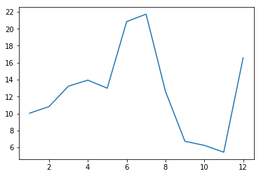

```python
#Plot departure delay grouped by month
dep_delay_by_month = flights_df.groupby(['month'])['dep_delay'].mean()
plt.plot(dep_delay_by_month)
plt.show()
```

There seems to be an increase in delays in the months of July and December which coincide with Independence Day and Christmas respectively. Due to it being festive season, there are more flights and that might be an explanation for the increased delays. Also in December, harsh weather can also be a contributor to the delays.

(d) On average, how do departure delays vary over the course of a day?

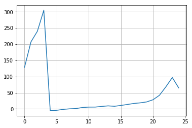

```python
#Plot departure delay grouped by hour
dep_delay_by_hour = flights_df.groupby(['hour'])['dep_delay'].mean()
plt.plot(dep_delay_by_hour)
plt.grid()
plt.show()
```

## Question 3

Which flight departing NYC in 2013 flew the fastest?

```python
#Calculate distance/airtime
flights_df[flights_df['distance']/flights_df['air_time'] == np.max(flights_df['distance']/flights_df['air_time'])]
```

|  | Unnamed: 0 | year | month | day | dep_time | dep_delay | arr_time | arr_delay | carrier | tailnum | flight | origin | dest | air_time | distance | hour | minute |
| --- | --- | --- | --- | --- | --- | --- | --- | --- | --- | --- | --- | --- | --- | --- | --- | --- | --- |
| 216447 | 216448 | 2013 | 5 | 25 | 1709.0 | 9.0 | 1923.0 | -14.0 | DL | N666DN | 1499 | LGA | ATL | 65.0 | 762 | 17.0 | 9.0 |

## Question 4

Which flights (i.e. carrier + flight + dest) happen every day? Where do they fly to?

```python
a = flights_df.groupby(['carrier','flight','dest'],as_index=False).count()

a = a.sort_values('Unnamed: 0', ascending = False)
#Here we are assuming that there is only one flight per day from New York City to that particular destination
a = a[(a.day == 365)]
a
```

|  | carrier | flight | dest | Unnamed: 0 | year | month | day | dep_time | dep_delay | arr_time | arr_delay | tailnum | origin | air_time | distance | hour | minute |
| --- | --- | --- | --- | --- | --- | --- | --- | --- | --- | --- | --- | --- | --- | --- | --- | --- | --- |
| 914 | AA | 1611 | MIA | 365 | 365 | 365 | 365 | 360 | 360 | 360 | 360 | 364 | 365 | 360 | 365 | 360 | 360 |
| 1243 | B6 | 703 | SJU | 365 | 365 | 365 | 365 | 364 | 364 | 364 | 364 | 365 | 365 | 364 | 365 | 364 | 364 |
| 904 | AA | 1357 | SJU | 365 | 365 | 365 | 365 | 364 | 364 | 364 | 363 | 364 | 365 | 363 | 365 | 364 | 364 |
| 10613 | VX | 413 | LAX | 365 | 365 | 365 | 365 | 362 | 362 | 362 | 360 | 365 | 365 | 360 | 365 | 362 | 362 |
| 1118 | B6 | 219 | CLT | 365 | 365 | 365 | 365 | 363 | 363 | 363 | 363 | 365 | 365 | 363 | 365 | 363 | 363 |
| 5116 | UA | 15 | HNL | 365 | 365 | 365 | 365 | 363 | 363 | 363 | 359 | 363 | 365 | 359 | 365 | 363 | 363 |
| 1147 | B6 | 359 | BUR | 365 | 365 | 365 | 365 | 364 | 364 | 364 | 364 | 365 | 365 | 364 | 365 | 364 | 364 |
| 1150 | B6 | 371 | FLL | 365 | 365 | 365 | 365 | 359 | 359 | 359 | 359 | 365 | 365 | 359 | 365 | 359 | 359 |
| 1169 | B6 | 431 | SRQ | 365 | 365 | 365 | 365 | 362 | 362 | 362 | 361 | 365 | 365 | 361 | 365 | 362 | 362 |
| 783 | AA | 181 | LAX | 365 | 365 | 365 | 365 | 363 | 363 | 363 | 362 | 365 | 365 | 362 | 365 | 363 | 363 |
| 2012 | DL | 2159 | MCO | 365 | 365 | 365 | 365 | 364 | 364 | 364 | 364 | 365 | 365 | 364 | 365 | 364 | 364 |
| 775 | AA | 119 | LAX | 365 | 365 | 365 | 365 | 361 | 361 | 361 | 359 | 364 | 365 | 359 | 365 | 361 | 361 |
| 10609 | VX | 407 | LAX | 365 | 365 | 365 | 365 | 364 | 364 | 363 | 363 | 365 | 365 | 363 | 365 | 364 | 364 |
| 4631 | EV | 5712 | IAD | 365 | 365 | 365 | 365 | 351 | 351 | 351 | 351 | 365 | 365 | 351 | 365 | 351 | 351 |
| 10607 | VX | 251 | LAS | 365 | 365 | 365 | 365 | 364 | 364 | 364 | 364 | 365 | 365 | 364 | 365 | 364 | 364 |
| 767 | AA | 59 | SFO | 365 | 365 | 365 | 365 | 359 | 359 | 359 | 359 | 363 | 365 | 359 | 365 | 359 | 359 |
| 1379 | B6 | 1783 | MCO | 365 | 365 | 365 | 365 | 365 | 365 | 365 | 365 | 365 | 365 | 365 | 365 | 365 | 365 |
| 2081 | DL | 2391 | TPA | 365 | 365 | 365 | 365 | 360 | 360 | 360 | 359 | 365 | 365 | 359 | 365 | 360 | 360 |

```python
#To clear that assumption, we look at the following grouped table

a = flights_df.groupby(['carrier','flight','dest','month','day'],as_index=False).count()
a[a['Unnamed: 0']>1]
```

|  | carrier | flight | dest | month | day | Unnamed: 0 | year | dep_time | dep_delay | arr_time | arr_delay | tailnum | origin | air_time | distance | hour | minute |
| --- | --- | --- | --- | --- | --- | --- | --- | --- | --- | --- | --- | --- | --- | --- | --- | --- | --- |

Above, you can see 18 flights running regularly. And also there is no flight which is flying twice or more on the same day. Hence, we can void our assumption

## Question 5

Develop one research question you can address using the nycflights2013 dataset. Provide two visualizations to support your exploration of this question. Discuss what you find.

### Which airlines should time-sensitive customers prefer while flying from New York to Seattle?

With this question we want to see which airlines should be prefereable for a time-sensitive customer from New York to Seattle. Hence, we will look at departure and arrival delays, average speed of each airline and also the number of flights for that airline in order to make a conclusion

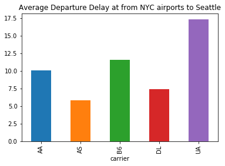

```python
#Average Departure Delay grouped by airlines
avg_dep_delay = nyctosea.groupby(['carrier'])['dep_delay'].mean()
avg_dep_delay.plot(kind='bar', x='origin',y='dep_delay',title='Average Departure Delay at from NYC airports to Seattle')
plt.show()
```

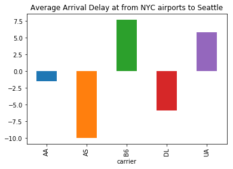

```python
#Average Arrival Delay grouped by airlines
avg_dep_delay = nyctosea.groupby(['carrier'])['arr_delay'].mean()
avg_dep_delay.plot(kind='bar', x='origin',y='arr_delay',title='Average Arrival Delay at from NYC airports to Seattle')
plt.show()
```

Here, we can see that Alaska Airlines has the lowest arrival delay amongst all the airlines flying from NYC to Seattle.

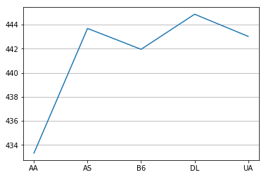

```python
nyctosea['speed_mph'] = nyctosea['distance']/(nyctosea['air_time']/60)
avg_speed = nyctosea.groupby(['carrier'])['speed_mph'].mean()
plt.plot(avg_speed)

plt.grid(axis='y', linestyle='-')

plt.show()
```

Here, we can see that Alaska Airlines has the second highest speed amongst all airlines.

```python
noofflights = nyctosea.groupby(['carrier'])['flight'].count()
noofflights
```

```
carrier
AA     365
AS     714
B6     514
DL    1213
UA    1117
Name: flight, dtype: int64
```

From the above results we conclude that a time-sensitive passenger should choose between Delta and Alaska Airlines while flying from NYC to Seattle.

## Question 6

What weather conditions are associated with flight delays leaving NYC? Use graphics to explore.

```python
#Merge both dataframes
weatherconditions = pd.merge(flights_df[['year','month','day','dep_delay','hour']], weather_df[['temp','dewp','humid','wind_dir','wind_speed','wind_gust','precip','visib']],  how='left', left_on=[flights_df.origin,flights_df.month, flights_df.day,flights_df.hour], right_on=[weather_df.origin,weather_df.month, weather_df.day,weather_df.hour])
```

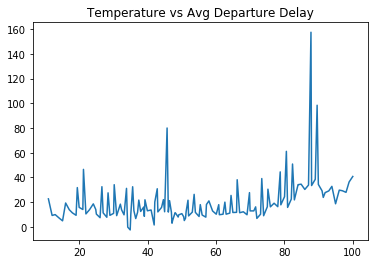

```python
#Plot temperature vs departure delay
temp = weatherconditions.groupby(['temp'])['dep_delay'].mean()
plt.plot(temp)
plt.title('Temperature vs Avg Departure Delay')
plt.show()
```

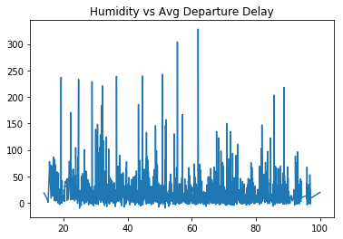

```python
#Plot humidity vs departure delay
temp = weatherconditions.groupby(['humid'])['dep_delay'].mean()
plt.plot(temp)
plt.title('Humidity vs Avg Departure Delay')
plt.show()
```

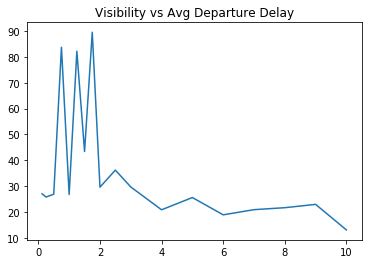

```python
#Plot visibility vs departure delay
temp = weatherconditions.groupby(['visib'])['dep_delay'].mean()
plt.plot(temp)
plt.title('Visibility vs Avg Departure Delay')
plt.show()
```

We can see that lower visibility plays a role in increasing delays as well as higher temperature has an effect on departure delay.

Humidity does not seem to have a greater effect on delays since the distribution seems to be uniform across the range of values.